# SM2 Assessed Coursework

Rachel Wood

2023-03-14

This portfolio considers a model for $n$ observations $\{ (y_i^0, x_i^0)\} \in \mathbb{R} \times \mathbb{R}^{p}$ defined by

$$\begin{equation} \label{model}
Y_i^0 \sim f(y;\mu_i, \phi)dy, \hspace{0.5cm} g(\mu_i) = \alpha +
f(x_i^0), \hspace{0.5cm} \text{for} i = 1, \ldots, n
\end{equation}$$
where $\alpha \in \mathbb{R}, \ \phi \in (0, \infty)$ and $f \in \mathcal{F} = \mathcal{H}_k$.

Here $(\mathcal{H_k}, \left< \cdot, \cdot \right>)$ is a reproducible kernel Hilbert space (RKHS) with positive semi definite kernel $k$. Then we have that $\mathcal{H}_k$ satisfies the reproducibility property

$$\begin{equation}
f(x) = \left< f, k(x, \cdot ) \right> \hspace{0.5cm} \forall x \in
\mathcal{X}, \forall f \in \mathcal{H}_k
\end{equation}$$

# Part 1

## Question 1

Here we consider the identifiability of ($\ref{model}$). A kernel will lead to identifiable models if and only if the corresponding RKHS does not contain constant functions.

We can take the kernel to be
$$k(x,y) = 1$$
which is positive semi-definite, we can see that taking $\H_k = \{ f: f(x) = c \ \forall x \}$ and $\left< f , g\right>_k = fg$ satisfies the reproducing property:
$$f(x) = \left< f,\ k(x, \cdot) \right> = \left< f, 1 \right>
= f \hspace{0.5cm} \forall x \in \mathcal{X}, \ \forall f \in
\mathcal{H}_k$$
and thus $(\mathcal{H}_k, \left< \cdot, \cdot \right>_k)$ is the corresponding RKHS. Since $\mathcal{H}_k$ is made up of constant functions, $k$ does not produce identifiable models.

An example of an identifiable kernel is the Gaussian kernel:
$$k_\lambda ( x, x')= \exp \left( - \frac{||x - x' ||^2}{\lambda}
\right)$$
Any function in the corresponding RKHS $f \in \mathcal{H}_k$ must satisfy:
$$f(x) = \left< f, k(x, \cdot)\right> = \frac{1}{\lambda} \left<
f, - \exp||x - \cdot ||^2 \right>$$
It is clear that there is no constant function $f$ (excepting the zero function) which satisfies this. Hence the Gaussian kernel leads to identifiable models.

## Question 2

For this question, we consider the solution $\hat f_\lambda$ to the optimisation problem

$$\begin{equation} \label{opt}
( \hat{\alpha_\lambda}, \hat{\phi_\lambda}, \hat{f_\lambda} ) \in
\argmax{\alpha \in \mathbb{R}, \phi \in (0, \infty), f \in \H_k}
\frac{1}{2n} \ \sum_{i = 1}^{n} \log f \left( y_i ; g^{-1} \left( \alpha
+ f(x_i^0) \right), \phi \right) - \lambda ||f||_{\H_k}^2
\end{equation}$$

We assume $\mathcal{H}_k = \tilde{\mathcal{H}_{n}} \oplus \tilde{\mathcal{H}_{n}}^{\perp}$, hence we can write $\hat f_\lambda = f_1 + f_2$ where $f_1 \in \tilde{\mathcal{H}_n}$ and $f_2 \in \tilde{\mathcal{H}_n}^{\perp}$. Thus there exists coefficients $\hat \beta_\lambda = \left( \hat \beta_{\lambda,1}, \ldots, \hat \beta_{\lambda,n} \right) \in \mathbb{R}^n$ such that

$$f_1 = \sum_{i = 1}^n \hat \beta_{\lambda,i} k(x_i^0, \cdot)$$

and we can write $f = \sum_{i = 1}^n \hat \beta_{\lambda,i} k(x_i^0, \cdot) + f_2$. Further, by the reproducing property, for any $x_j$:

$$f(x_j) = \left< \sum_{i = 1}^n \hat \beta_{\lambda,i} k(x_i^0, \cdot)
+ f_2, \ k(x_j^0,\cdot) \right> = \sum_{i = 1}^n \hat
\beta_{\lambda,i} \left< k(x_i^0, \cdot), k(x_j^0, \cdot) \right>
= \sum_{i = 1}^n \hat \beta_{\lambda,i} k(x_i^0, x_j^0)$$

and so $f(x_j)$ does not depend on $f_2$ and as a consequence, the first term in ($\ref{opt}$) also does not depend on $f_2$. Hence to choose $f_2$ we only need to consider minimizing the regularisation term. Using that $\left<f_1, f_2 \right> = 0$, we see

$$||f||_{\mathcal{H}_k}^2 = \left< f_1 +f_2, f_1 +f_2 \right> =
||f_1||_{\mathcal{H}_k}^2 + ||f_2||_{\mathcal{H}_k}^2 \geq
||f_1||_{\mathcal{H}_k}^2$$

with the last inequality becoming an equality when $f_2 = 0$. Hence the minimiser $\hat f_\lambda$ must have $f_2 = 0$ and can be written as

$$\begin{equation} \label{f_sol}
\hat f_\lambda = \sum_{i = 1}^n \hat \beta_{\lambda,i} k(x_i^0, \cdot)
\end{equation}$$

## Question 3

We now want to substitute the results of ($\ref{f_sol}$) into ($\ref{opt}$). The regularisation term becomes:

$$\begin{align*}
||f||_{\H_k}^2 &= \left< \sum_{i = 1}^n \hat \beta_{\lambda,i}
k(x_i^0, \cdot), \sum_{i = j}^n \hat \beta_{\lambda,j} k(x_j^0, \cdot)
\right> \\
&= \sum_{i = 1}^{n} \sum_{j = 1}^n \hat \beta_{\lambda,i} \left<
k(x_i^0, \cdot), k(x_j^0, \cdot) \right> \hat \beta_{\lambda,j} \\
&= \sum_{i = 1}^{n} \sum_{j = 1}^n \hat \beta_{\lambda,i} k(x_i^0,
x_j^0) \hat \beta_{\lambda,j} \\
&= \hat \beta_\lambda^T K \hat \beta_\lambda
\end{align*}$$

and so ($\ref{opt}$) becomes

$$\begin{equation} \label{new_opt}
(\hat{\alpha_\lambda}, \hat{\phi_\lambda}, \hat{\beta_\lambda} ) \in
\argmax{\alpha \in \mathbb{R}, \phi \in (0, \infty), \beta \in
\mathbb{R}^n} \ \frac{1}{2n} \sum_{i = 1}^{n} \log f \left( y_i ; g^{-1}
\left( \alpha + \sum_{j = 1}^n \beta_{i} k(x_i^0, x_j^0) \right), \phi
\right) - \lambda \beta^T K \beta
\end{equation}$$

## Question 4

The Nyström method approximates $k$ by $\tilde{f}^{(m)} = k^{(m)}$, given by

$$\tilde k^{(d)} ( x, x') = k_d (x)^T K_{d,d}^{-1} \ k_d(x')$$

where $K_{d, d} \in \mathbb{R}^{d\times d}$ is the first $d$ rows and columns of the gram matrix $K$ and $k_d (x) = (k(x_1^0,x), \ldots, k(x_d^0, x))$

Then we can write $f(x)$ as
$$f =\sum_{i = 1}^n \beta_{i}\ \tilde k_d(x_i^0, \cdot) = \sum_{i = 1}^n
\beta_{i}\ k_d (x_i^0)^T K_{d,d}^{-1} \ k_d(\cdot) = \left( \sum_{i =
1}^n \beta_{i}\ k_d (x_i^0)^T K_{d,d}^{-1} \right) k_d(\cdot)$$

and take the new vector of coefficients to be:
$$\tilde \beta^T = \sum_{i = 1}^n \beta_{i}\ k_d (x_i^0)^T \left( K_d^0
\right)^{-1} = \beta^T K_{n,d} K_{d,d}^{-1}$$

where $K_{n,d} \in \mathbb{R}^{n \times d}$ is the first $d$ columns of $K$ We can now rewrite $f$ as:

$$f = \tilde \beta^T k_d(\cdot) = \sum_{j =1}^d \tilde \beta_j k(x_j,
\cdot)$$

We now consider the regularisation term, again we substitute $\tilde k^{(d)}$:

$$\beta^T \tilde K^{(d)} \beta = \beta^T K_{n,d}\ K_{d,d}^{-1} \
K_{n,d}^T \ \beta = \left(\beta^T K_{n,d} \ K_{d,d}^{-1} \right)
K_{d,d}^T \left( K_{d,d}^{-T}\ K_{n,d}\ \beta \right) = \tilde \beta^T
K_{d,d}^T \ \tilde \beta$$

Hence we can now write our $m$-dimension optimisation problem:

$$\begin{equation} \label{m_opt}
(\hat{\alpha_\lambda}, \hat{\phi_\lambda}, {\tilde \beta_\lambda} ) \in
\argmax{\alpha \in \mathbb{R}, \phi \in (0, \infty), \tilde \beta \in
\mathbb{R}^d} \ \frac{1}{2n} \sum_{i = 1}^{n} \log f \left( y_i ; g^{-1}
\left( \alpha + \sum_{j =1}^d \tilde \beta_j k(x_j, x_i) \right), \phi
\right) - \lambda \tilde \beta^T K_{d,d}^T \ \tilde \beta
\end{equation}$$

## Question 5

For this question we first need to obtain the penalty term as $\omega ^T \omega$ for some vector $\omega$. We can first obtain the eigen-decomposition of $K_{d,d}^T$:
$$K_{d,d}^T = V \Lambda V^T$$
Then writing $\Lambda = \Lambda^{\frac{1}{2}} \Lambda^{\frac{1}{2}} = \Lambda^{\frac{1}{2}} \left(\Lambda^{\frac{1}{2}}\right)^T$, we get
$$\tilde \beta^T K_{d,d} \ \tilde \beta = \tilde \beta^T V
\Lambda^{\frac{1}{2}} \left(\Lambda^{\frac{1}{2}}\right)^T V^T \tilde
\beta = \omega^T \omega$$

where $\omega^T = \tilde \beta^T V \Lambda^{\frac{1}{2}}$, or equivalently $\tilde \beta^T = \omega^T \Lambda^{- \frac{1}{2}} V^T$.

Then our objective function becomes

$$\begin{equation}
(\hat{\alpha_\lambda}, \hat{\phi_\lambda}, \hat \omega_\lambda ) \in
\argmax{\alpha \in \mathbb{R}, \phi \in (0, \infty), \omega\in
\mathbb{R}^d} \ \frac{1}{2n} \sum_{i = 1}^{n} \log f \left( y_i ; g^{-1}
\left( \alpha + \omega^T \Lambda^{- \frac{1}{2}} V^T K_{d,n} \right),
\phi \right) - \lambda \omega^T \omega
\end{equation}$$

so we can use $X' = \Lambda^{- \frac{1}{2}} V^T K_{n,d}$, where $K$ is the Gram matrix of the original data, as the input for `glmnet()` and this will give the estimated $\omega$.

# Part 2

This section implements the theory from Part 1 on the `wesdr` data from the `gss` package, which has the binary response variable `ret` and explanatory variables `dur`, `gly` and `bmi`

```r
library(dplyr)
library(kableExtra)
library(gss)
data("wesdr")
head(wesdr)
```

```
##    dur  gly  bmi ret
## 1 10.3 13.7 23.8   0
## 2  9.9 13.5 23.5   0
## 3 15.6 13.8 24.8   0
## 4 26.0 13.0 21.6   1
## 5 13.8 11.1 24.6   1
## 6 31.1 11.3 24.6   1
```

We also separate the explanatory and response variables and construct a testing and training set:

```r
X <- as.matrix(wesdr[,1:3])
y <- as.vector(wesdr[,4])

train <- sample(1:nrow(X), 500)
X_train <- X[train,]
y_train <- y[train]

X_test <- X[-train,]
y_test <- y[-train]
```

## Question 6

We can now use `glmnet` to write a function implementing Question 4 and 5:

```r
library(kernlab)
library(glmnet)
estimate <- function(X, y, lambda, c, m){
  d <- m - 1
  K <- kernelMatrix(kernel = rbfdot(c), x = X)
  K_d <- K[1:d, 1:d]

  K_eigen <- eigen(K_d)
  V <- K_eigen$vectors
  Lambda <- (K_eigen$values)

  K_nd <- K[1:d,]
  X_new <- diag(1/sqrt(Lambda)) %*% t(V) %*% K_nd


  fit <- glmnet(t(X_new), y, family = "binomial", alpha = 0, lambda = lambda)

  alpha <- fit$a0
  omega <- as.vector(fit$beta)

  beta <- omega %*% diag(1/sqrt(Lambda)) %*% t(V)

  values <- list("alpha" = alpha, "beta" = beta, "fit" = fit)
  return(values)
}
```

## Question 7

For certain values of $m$, $c$ and $lambda$ the `X_new` matrix contains some `NaN` values, for example we try the following values:

```r
c <- 1e-04
m <- 60
lambda <- 0.1
epsilon = 0.001

estimate <- estimate(X, y, lambda, c, m)
```

```
## Error in glmnet(t(X_new), y, family = "binomial", alpha = 0, lambda = lambda): x has missing values; consider using makeX() to impute them
```

This is because some of the eigenvalues of $K$ are small enough that they are represented as `0` in a floating point number. To remedy this we can replace the kernel matrix with the altered $K_d' = K_d + epsilon I$ for a small $\epsilon$

```r
estimate_new <- function(X, y, lambda, c, m, epsilon = 0.001){
  d <- m - 1
  K <- kernelMatrix(kernel = rbfdot(c), x = X)
  K_d <- K[1:d, 1:d] + epsilon* diag(rep(1,d))

  K_eigen <- eigen(K_d)
  V <- K_eigen$vectors
  Lambda <- (K_eigen$values)

  K_nd <- K[1:d,]
  X_new <- diag(1/sqrt(Lambda)) %*% t(V) %*% K_nd


  fit <- glmnet(t(X_new), y, family = "binomial", alpha = 0, lambda = lambda)

  alpha <- fit$a0
  omega <- as.vector(fit$beta)

  beta <- omega %*% diag(1/sqrt(Lambda)) %*% t(V)

  values <- list("alpha" = alpha, "beta" = beta, "fit" = fit)
  return(values)
}
```

and we can see now that this does not produce any errors

```r
estimate <- estimate_new(X_train, y_train, lambda, c, m)
```

## Question 8

Here we want to choose $\lambda$ using cross-validation, the `glmnet` package enables us to do this using the `cv.glmnet()` function, which uses the deviance to perform $k$-fold cross-validation. We use the following function to obtain the solution to ($\ref{m_opt}$) for the cross-validated value of $\lambda$:

```r
lambda_cv_estimate <- function(X, y, c, m,  epsilon = 0.01){
  d <- m - 1
  K <- kernelMatrix(kernel = rbfdot(c), x = X)
  K_d <- K[1:d, 1:d]

  K_eigen <- eigen(K_d)

  V <- K_eigen$vectors
  Lambda <- (K_eigen$values) + epsilon * (rep(1,d))

  K_nd <- K[1:d,]
  X_new <- diag(1/sqrt(Lambda)) %*% t(V) %*% K_nd

  cv_fit <- cv.glmnet(t(X_new), y, family = "binomial", alpha = 0)

  lambda <- cv_fit$lambda.min
  lambda_ind <- cv_fit$index[1]

  fits <- cv_fit$glmnet.fit

  alpha <- fits$a0[lambda_ind]
  omega <- as.vector(fits$beta[,lambda_ind])

  beta <- omega %*% diag(1/sqrt(Lambda)) %*% t(V)

  values <- list("alpha" = alpha, "beta" = beta, "lambda" = lambda, "cvm" = cv_fit$cvm[lambda_ind], "fit" = fits, "K" = K)
  return(values)
}
```

```r
fit <- lambda_cv_estimate(X, y, 1, 100)
```

## Question 9

We can now use the function from to write a function which performs a grid search to choose the optimal value for `c`:

```r
c_cv_estimate <- function(X, y, m){
  c = c(0.0001, 0.0005, 0.0008, 0.001, 0.003, 0.005, 0.01, 0.05, seq(0.1, 1, 0.1), 1.5,2, 2.5)

  l <- length(c)

  alphas <- numeric(l)
  betas <- matrix(nrow = l, ncol = m - 1)

  lambdas <- numeric(l)
  cvms <- numeric(l)

  fits <- vector(mode = "list", length = l)

  Ks <- vector(mode = "list", length = l)

  for (i in 1:l) {
    est <- lambda_cv_estimate(X, y, c[i], m)

    alphas[i] <- est$alpha
    betas[i,] <- est$beta

    lambdas[i] <- est$lambda
    cvms[i] <- est$cvm

    fits[[i]] <- est$fit

    Ks[[i]] <- est$K
  }

  min_ind <- which.min(cvms)

  values <- list("alpha" = alphas[min_ind], "beta" = betas[min_ind, ], "lambda" = lambdas[min_ind], "c" = c[min_ind], cvm = cvms[min_ind], "fit" = fits[[min_ind]], "K" = Ks[[min_ind]])
  return(values)
}
```

We can now use the training dataset to obtain the solution when `c` and `lambda` are chosen with cross-validation:

```r
parameters <- c_cv_estimate(X_train, y_train, m =150)
```

## Question 10

We can now use the output of the function above, the training set and test set to produce the estimated response vector for the test set: for various a range of `m` values

```r
set.seed(1)
m <- c(10,20,30,50,70,100,150,200,300)
n <- length(m)

responses <- matrix(nrow = length(y_test), ncol = n)
for (i in 1:n){
  model <-  c_cv_estimate(X_train, y_train, m[i])

  fit <- model$fit

  c <- model$c

  K <- model$K
  d <- m[i] -1
  K_d <- K[1:d, 1:d]

  K_eigen <- eigen(K_d)

  V <- K_eigen$vectors
  Lambda <- (K_eigen$values) + epsilon * rep(1,d)

  K_prime <- kernelMatrix(kernel = rbfdot(c), x = X_test, y = X_train)
  K_prime_ld <- K_prime[,1:d]


  X_test_new <-  diag(1/sqrt(Lambda)) %*% t(V) %*% t(K_prime_ld)

  omega <- model$beta %*% V %*% diag(sqrt(Lambda))
  eta <- model$alpha + t(X_test_new) %*% t(omega)

  pred_response <-round(1 / (1+ exp(-eta)))

  responses[,i] <- pred_response
}
```

We can now plot the predicted errors for different values of `m`:

```r
library(dplyr)
pred_error <- colMeans(abs(responses - y_test))

plot_dat <- cbind("m" = m, "Prediction Error" = pred_error) %>%
  as_tibble()
```

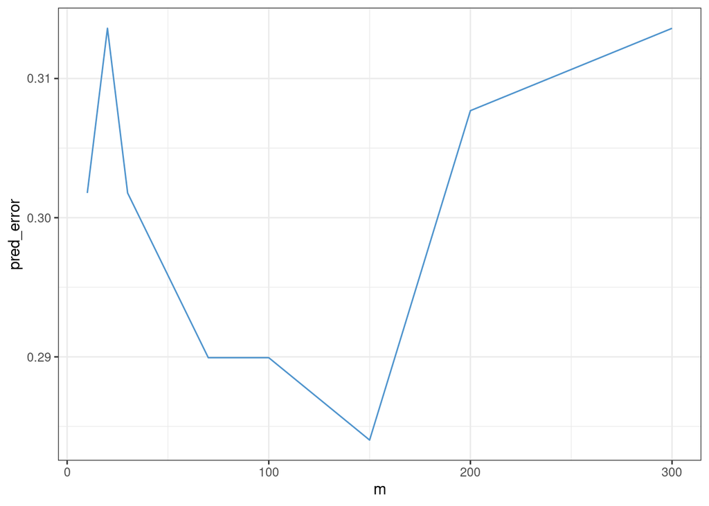

```r
library(ggplot2)

ggplot(plot_dat) +
  geom_line(aes(x = m, y = pred_error), color = "steelblue3")
```

We can see the lowest prediction error is at `m = 150`, with a value of $\approx 0.28$, hence we can get a prediction that performs better than a guess but is still not excellent.

## Question 11

We can use a GAM to approximate the model given in ($\ref{model}$):

```r
library(mgcv)

fit_gam <- gam(ret ~ s(dur, bs = "cr") + s(gly, bs = "cr") + s(bmi, bs = "cr"), data = wesdr[train,], family = "binomial")

test_pred <- predict(fit_gam, wesdr[-train,], type = "response")

gam_error <- mean(abs(round(test_pred) - y_test))
gam_error
```

```
## [1] 0.295858
```

We can see here the prediction error is very similar and there doesn’t seem to be much different within the models